# Road Data Site Report

DataSciT39

Monday-04-Jan-2021

# Site Report for Dates 01072019 to 01072019.

## All Site Types: Empty API Responses

[figure not shown]

This means that **0 % (rounded)** of the IDs contained no content for this date range.

## Empty Responses by Site Type

### MIDAS

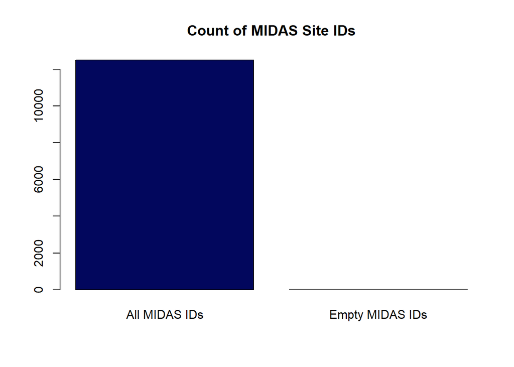

There were **12,499** site IDs of the MIDAS type.

Of these IDs, **0** of the queries returned **no content** (HTTP response [code 204](https://httpstatuses.com/204)).

This means that **0 % (rounded)** of the MIDAS IDs contained no content for this date range.

#### Empty Responses: MIDAS Site Details

| row_count | sites.Id | sites.Name | sites.Description | sites.Status | type |
| --- | --- | --- | --- | --- | --- |

### TAME

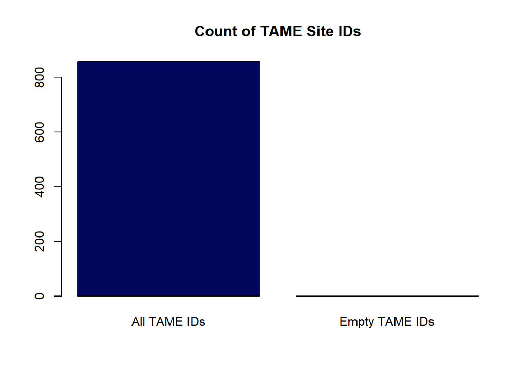

There were **859** site IDs of the TAME type.

Of these IDs, **0** of the queries returned **no content** (HTTP response [code 204](https://httpstatuses.com/204)).

This means that **0 % (rounded)** of the TAME IDs contained no content for this date range.

#### Empty Responses: TAME Site Details

| row_count | sites.Id | sites.Name | sites.Description | sites.Status | type |
| --- | --- | --- | --- | --- | --- |

### TMU

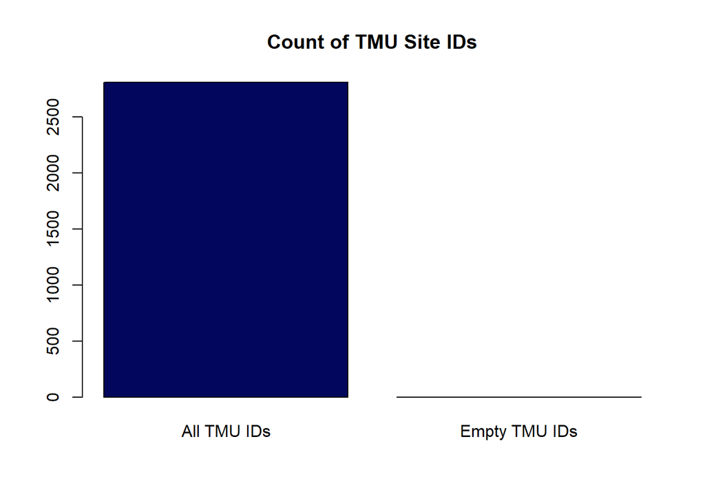

There were **2,807** site IDs of the TMU type.

Of these IDs, **0** of the queries returned **no content** (HTTP response [code 204](https://httpstatuses.com/204)).

This means that **0 % (rounded)** of the TMU IDs contained no content for this date range.

#### Empty Responses: TMU Site Details

| row_count | sites.Id | sites.Name | sites.Description | sites.Status | type |
| --- | --- | --- | --- | --- | --- |

## Join Integrity

If any output appears within this section, it indicates that there are readings within the `combo` DataFrame that have no matching site information in the `sites` DataFrame.

```
## [1] "No null matches were found in the combo dataframe this run."
```